# STAT656: Homework 4

# Introduction

A major issue with antiretroviral drugs is the mutation of the virus’ genes. Because of its high rate of replication ($10^9$ to $10^{10}$ virus per person per day) and error-prone polymerase, HIV can easily develop mutations that alter susceptibility to antiretroviral drugs. The emergence of resistance to one or more antiretroviral drugs is one of the more common reasons for therapeutic failure in the treatment of HIV.

In the paper ‘Genotypic predictors of human immunodeficiency virus type 1 drug resistance’, a sample of in vitro HIV viruses were grown and exposed to a particular antiretroviral therapy. We have a measurement which is the susceptibility of the virus to treatment, in which larger values indicate less susceptible. It has been log transformed. As well, we have whether there is a genetic mutation on each of 208 genes for each virus (each virus is a different row or observation). It is composed of 0’s and 1’s, with a 1 indicating a mutation in a particular gene.

# Problem 1 (10 pts)

```r
load("hiv.rda")

X = hiv.train$x
Y = hiv.train$y

geneLabels = colnames(X)
```

## Problem 1.1

What are n and p in this problem?

#### Answer 1.1.1.

```r
n = dim(X)[1]
p = dim(X)[2]
```

The number of observations is 704 and the number of features is 208.

#### Answer 1.1.2.

What are the features in this problem? What are the observations? What is the supervisor? What do larger values for the supervisor indicate in terms of susceptibility?

There are 208 genes in each virus, each feature represents the occurrence of genetic mutation in a particular gene.

Each observation is a HIV virus which is grown for the purpose of the experiment.

The supervisor is a measure of the likelihood of a virus being altered by a treatment.

# Problem 2 (10 pts)

Consider the feature matrix X. Look at the output for the following chunk of code.

```r
table(X)
```

```
## X
##      0      1
## 135589  10843
```

#### Answer 2.1

What do these results indicate?

There are comparatively few instances of genetic mutation in our training set, most features are set to zero. This indicates that a sparse matrix could provide computational and time savings.

# Problem 3 (10 pts)

The supervisor is the log transformed susceptibility of a virus to the considered treatment, with large values indicating the virus is relatively more resistant (that is, not susceptible).

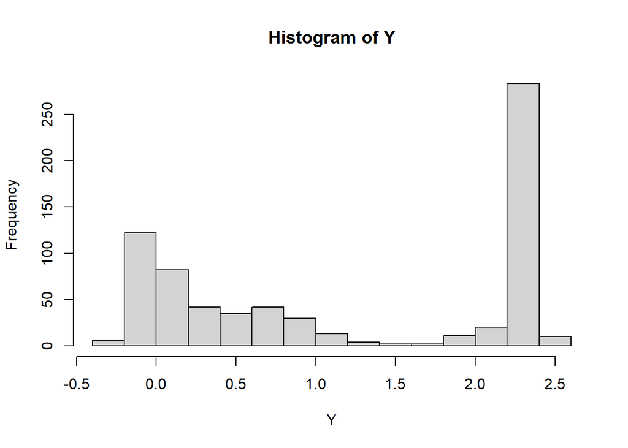

```r
hist(Y)
```

#### Answer 3.1

What do these results indicate? (Note that even though the supervisor doesn’t look symmetric, we will still apply elastic net to it, as did the authors in that paper I included. We won’t consider further transformations of the supervisor)

This histogram indicates left skewness in the distribution of log-transformed susceptibility. The distribution also appears multi-modal. Both results complicate any approach that relies on estimating the expected value of the supervisor, as the mean is not an appropriate measure of central tendency in this case. Such approaches are any variation on multiple linear regression such as lasso regression, ridge regression or, more generally, any elastic net setting.

# Problem 4 (70 pts)

We may have (at least) two goals with a data set such as this:

- inference: can we find some genes whose mutation seems to be most related to viral susceptibility?
- prediction: can we make a model that would predict whether this therapy would be efficacious, given a virus with a set of genetic mutations

## Problem 4.1. Inference

Find the estimated coefficient vectors for the following procedures

- lasso
- refitted lasso

### Problem 4.1.1. Lasso

Now, find the CV minimizing lasso solution

#### Answer 4.1.1.

```r
require(glmnet)
lassoOut     = cv.glmnet(X ,Y, alpha=1, standardize = FALSE) #Consider why we wouldn't standardize
betaHatLasso = coef(lassoOut, s = lassoOut$lambda.min)
Slasso       = glmnet(x = X, y = Y, alpha = 1, s = lassoOut$lambda.min,
                      standardize = FALSE)
```

### Problem 4.1.2. Refitted lasso

Now, find the refitted lasso using the ‘1 standard error rule’ lambda and refitting with least squares. I’ve included a plot of CV so that you can see the lambda.1se solution.

#### Answer 4.1.2.

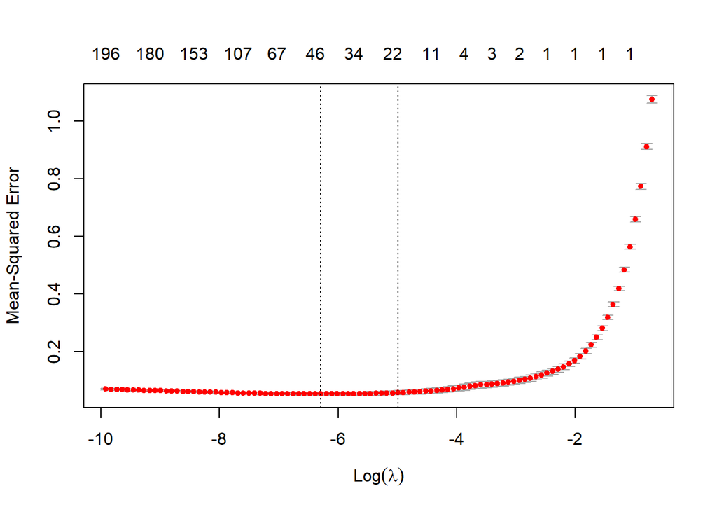

```r
plot(lassoOut)
```

```r
betaHatTemp     = coef(lassoOut, s = lassoOut$lambda.1se)[-1]
Srefitted       = which(abs(betaHatTemp) > 1e-16)
Xdf             = as.data.frame(X[,Srefitted])
refittedOut     = lm(Y ~ ., data = Xdf)
betaHatRefitted = coef(refittedOut)
```

#### Answer 4.1.3

What are the genes selected by the refitted lasso (that is, what are the ‘geneLabels’ (the feature names) that correspond to the nonzero coefficients in the coefficient vector)?

```r
cat('The selected genes from refitted lasso are: \n',
     colnames(Xdf),'\n')
```

```
## The selected genes from refitted lasso are:
##  p21 p33 p41 p43 p65 p67 p69 p75 p83 p90 p118 p151 p162 p181 p184 p190 p200 p210 p215 p219 p228
```

### Problem 4.1.4

For the refitted lasso, which gene is associated with the largest DECREASE in viral susceptibility (note: remember how the supervisor is coded) to this particular drug?

#### Answer 4.1.4

```r
gene_ld_index = which.max(coef(refittedOut))
gene_ld = coef(refittedOut)[gene_ld_index]
gene_ld_label = names(coef(refittedOut)[gene_ld_index])
```

The gene associated with the largest decrease in viral susceptibility is p184.

#### Answer 4.1.5

Interpret this estimated coefficient within the context of the problem

## Problem 4.2. Prediction

Now, let’s look at some predictions made by these methods. Use the following for the test set:

```r
Xtest = hiv.test$x
Ytest = hiv.test$y
```

Let’s compute the test error (that is the loss evaluated on this test data)

- ridge
- lasso
- refitted lasso

We can get the predictions out via various ‘predict’ functions

### Problem 4.2.1. Ridge regression at lambda.min

Now that we are looking at prediction, we can use ridge regression (which mainly is used for prediction). Using the package glmnet, let’s plot the CV curve over the grid of lambda values and indicate the minimum, and finally report the CV estimate of the test error for ridge at each lambda.

There is no need to report the p coefficient estimates from the ridge solution. Also, glmnet has a grid problem. The automatically allocated grid by glmnet has a minimum value that is too small and hence we get a `boundary’ solution. Let’s make two plots, one that shows the CV plot with and one without this boundary issue

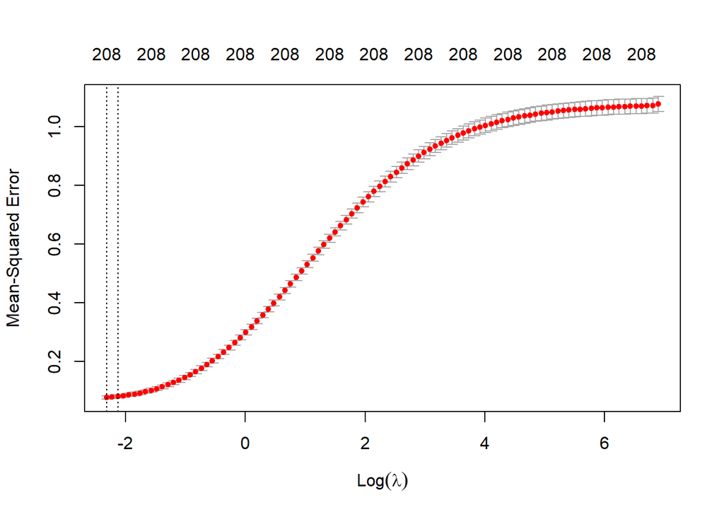

```r
ridgeOut = cv.glmnet(X,Y,alpha=0)
plot(ridgeOut) #This has the boundary issue
```

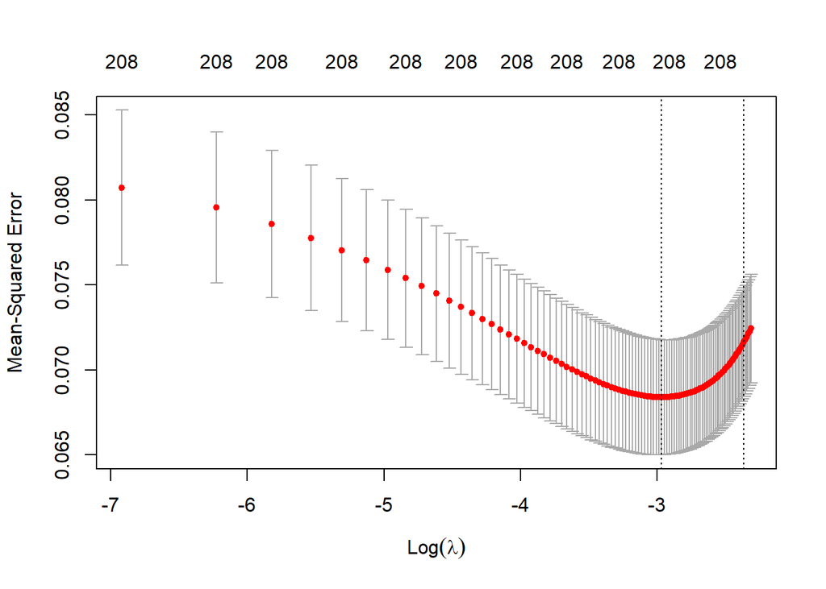

```r
minLambda = min(ridgeOut$lambda)
lambdaNew = seq(minLambda, minLambda*0.01,length=100)
ridgeOut  = cv.glmnet(x = X, y = Y, alpha = 0,lambda = lambdaNew)
plot(ridgeOut)
```

```r
YhatTestRidge = predict(ridgeOut, Xtest, s = 'lambda.min')
```

#### Answer 4.2.1.

Why is a boundary solution for minimizing CV an issue?

A boundary solution isn’t the true solution in minimizing CV error, we aren’t exploring the full range of possible $\lambda$.

### Problem 4.2.2. Lasso

We can use the previously computed lasso object to get the predictions

```r
YhatTestLasso = predict(lassoOut, Xtest, s = 'lambda.min')
```

#### Answer 4.2.3. Refitted lasso

Get the predictions for the refitted lasso. Remember, choose lambda via the 1se rule and then fit the least squares solution on the selected features.

```r
YhatTestRefitted = predict(refittedOut, data.frame(Xtest))
```

#### Answer 4.2.4. Getting the test errors

```r
# Get the test error
testErrorRidge    = mean((YhatTestRidge - Ytest)^2)
testErrorLasso    = mean((YhatTestLasso - Ytest)^2)
testErrorRefitted = mean((YhatTestRefitted - Ytest)^2)
```